# Analysing large data - Solution

Aksel Thomsen

Statistical Programming with R

In this exercise we will try to recreate a map of sailing rutes in Denmark. It is a good example on how you can gain a lot of information by applying a quite simple analysis to a large amount of data.

## Problem 1

Here we want to only keep the relevant information in the data. The analysis requires the position of the moving ships.

One way of restricting the data is as follows:

1. Read any one of the csv files into R
2. Select only the relevant variables
3. Filter so you only have the relevant observations

**Solution**

```r
library(tidyverse)
df1 <- readr::read_csv("aisdk_201902.csv")
```

```r
head(df1)
```

```
## # A tibble: 6 x 26
##   `# Timestamp` `Type of mobile`   MMSI Latitude Longitude `Navigational s~
##   <chr>         <chr>             <dbl>    <dbl>     <dbl> <chr>
## 1 02/12/2019 0~ Base Station     2.19e6     56.3      4.27 Unknown value
## 2 02/12/2019 0~ Class A          3.11e8     55.3      5.96 Under way using~
## 3 02/12/2019 0~ Class A          2.59e8     56.3     12.4  Under way using~
## 4 02/12/2019 0~ Class A          5.66e8     57.5     11.6  Under way using~
## 5 02/12/2019 0~ Class A          2.19e6     55.5      8.42 Unknown value
## 6 02/12/2019 0~ Class A          2.20e8     56.0     11.8  Unknown value
## # ... with 20 more variables: ROT <dbl>, SOG <dbl>, COG <dbl>, Heading <dbl>,
## #   IMO <chr>, Callsign <chr>, Name <chr>, `Ship type` <chr>, `Cargo
## #   type` <chr>, Width <dbl>, Length <dbl>, `Type of position fixing
## #   device` <chr>, Draught <dbl>, Destination <chr>, ETA <chr>, `Data source
## #   type` <chr>, A <dbl>, B <dbl>, C <dbl>, D <dbl>
```

```r
df2 <- df1 %>%
  select(Latitude,Longitude,SOG) %>%
  filter(!is.na(SOG),SOG>0)
```

```r
head(df2)
```

```
## # A tibble: 6 x 3
##   Latitude Longitude   SOG
##      <dbl>     <dbl> <dbl>
## 1     55.3      5.96  10.6
## 2     56.3     12.4    8.6
## 3     57.5     11.6    9.6
## 4     55.8     10.9   16
## 5     54.6     10.9   11.9
## 6     54.9     13.3   12.4
```

## Problem 2

Can you apply the same restrictions to all five CSV files and combine them to one data ready for analysis?

If you are running out of RAM use the `n_max` argument to `readr::read_csv` to limit how many observations you include. For this specific problem it is okay not include all.

**Solution**

```r
ais_files <- list.files(pattern = "aisdk")

ais_files
```

```
## [1] "aisdk_201901.csv" "aisdk_201902.csv" "aisdk_201903.csv" "aisdk_201904.csv"
## [5] "aisdk_201905.csv"
```

I use `n_max=1000` so I don’t run out of memory.

```r
df1_all <- purrr::map(.x = ais_files, .f = readr::read_csv, n_max = 1000)
```

```r
map(df1_all, head, 5)
```

```
## [[1]]
## # A tibble: 5 x 26
##   `# Timestamp` `Type of mobile`   MMSI Latitude Longitude `Navigational s~
##   <chr>         <chr>             <dbl>    <dbl>     <dbl> <chr>
## 1 01/12/2019 0~ Class A          3.57e8     55.1     15.6  Under way using~
## 2 01/12/2019 0~ Base Station     2.19e6     56.3      4.27 Unknown value
## 3 01/12/2019 0~ Base Station     2.19e6     55.5      5.03 Unknown value
## 4 01/12/2019 0~ Base Station     2.19e6     56.7     11.5  Unknown value
## 5 01/12/2019 0~ Class A          2.20e8     56.0      8.12 Restricted mane~
## # ... with 20 more variables: ROT <dbl>, SOG <dbl>, COG <dbl>, Heading <dbl>,
## #   IMO <chr>, Callsign <chr>, Name <chr>, `Ship type` <chr>, `Cargo
## #   type` <chr>, Width <dbl>, Length <dbl>, `Type of position fixing
## #   device` <chr>, Draught <dbl>, Destination <chr>, ETA <chr>, `Data source
## #   type` <chr>, A <dbl>, B <dbl>, C <dbl>, D <dbl>
##
## [[2]]
## # A tibble: 5 x 26
##   `# Timestamp` `Type of mobile`   MMSI Latitude Longitude `Navigational s~
##   <chr>         <chr>             <dbl>    <dbl>     <dbl> <chr>
## 1 02/12/2019 0~ Base Station     2.19e6     56.3      4.27 Unknown value
## 2 02/12/2019 0~ Class A          3.11e8     55.3      5.96 Under way using~
## 3 02/12/2019 0~ Class A          2.59e8     56.3     12.4  Under way using~
## 4 02/12/2019 0~ Class A          5.66e8     57.5     11.6  Under way using~
## 5 02/12/2019 0~ Class A          2.19e6     55.5      8.42 Unknown value
## # ... with 20 more variables: ROT <dbl>, SOG <dbl>, COG <dbl>, Heading <dbl>,
## #   IMO <chr>, Callsign <chr>, Name <chr>, `Ship type` <chr>, `Cargo
## #   type` <chr>, Width <dbl>, Length <dbl>, `Type of position fixing
## #   device` <chr>, Draught <dbl>, Destination <chr>, ETA <chr>, `Data source
## #   type` <chr>, A <dbl>, B <dbl>, C <dbl>, D <dbl>
##
## [[3]]
## # A tibble: 5 x 26
##   `# Timestamp` `Type of mobile`   MMSI Latitude Longitude `Navigational s~
##   <chr>         <chr>             <dbl>    <dbl>     <dbl> <chr>
## 1 03/12/2019 0~ Base Station     2.19e6     56.7     11.5  Unknown value
## 2 03/12/2019 0~ Class A          2.19e8     57.4     10.5  Moored
## 3 03/12/2019 0~ Base Station     2.19e6     55.5      5.03 Unknown value
## 4 03/12/2019 0~ Base Station     2.19e6     56.3      4.27 Unknown value
## 5 03/12/2019 0~ Class A          2.28e8     55.8      7.28 Restricted mane~
## # ... with 20 more variables: ROT <dbl>, SOG <dbl>, COG <dbl>, Heading <dbl>,
```

[output cut: 19 more lines]

```
##
## [[5]]
## # A tibble: 5 x 26
##   `# Timestamp` `Type of mobile`   MMSI Latitude Longitude `Navigational s~
##   <chr>         <chr>             <dbl>    <dbl>     <dbl> <chr>
## 1 05/12/2019 0~ Class A          2.57e8     57.1      8.59 Restricted mane~
## 2 05/12/2019 0~ Class A          2.12e8     55.3     14.4  Under way using~
## 3 05/12/2019 0~ Class A          2.19e8     57.7     10.6  Engaged in fish~
## 4 05/12/2019 0~ Class A          2.66e8     57.6     11.8  Under way using~
## 5 05/12/2019 0~ Class A          3.78e8     55.1     11.0  Under way using~
## # ... with 20 more variables: ROT <dbl>, SOG <dbl>, COG <dbl>, Heading <dbl>,
## #   IMO <chr>, Callsign <chr>, Name <chr>, `Ship type` <chr>, `Cargo
## #   type` <chr>, Width <dbl>, Length <dbl>, `Type of position fixing
## #   device` <chr>, Draught <dbl>, Destination <chr>, ETA <chr>, `Data source
## #   type` <chr>, A <dbl>, B <dbl>, C <dbl>, D <dbl>
```

```r
df2_all <- df1_all %>%
  purrr::map(
    ~ .x %>%
      select(Latitude,Longitude,SOG) %>%
      filter(!is.na(SOG),SOG>0)
  )

map(df2_all, head, 5)
```

```
## [[1]]
## # A tibble: 5 x 3
##   Latitude Longitude   SOG
##      <dbl>     <dbl> <dbl>
## 1     55.1     15.6   12.7
## 2     56.4     11.5   12.1
## 3     57.0      8.25  10.1
## 4     58.0      9.59   2.8
## 5     55.5      8.13   2.7
##
## [[2]]
## # A tibble: 5 x 3
##   Latitude Longitude   SOG
##      <dbl>     <dbl> <dbl>
## 1     55.3      5.96  10.6
## 2     56.3     12.4    8.6
## 3     57.5     11.6    9.6
## 4     55.8     10.9   16
## 5     54.6     10.9   11.9
##
## [[3]]
## # A tibble: 5 x 3
##   Latitude Longitude   SOG
##      <dbl>     <dbl> <dbl>
## 1     55.8      7.28   0.2
## 2     55.0     11.8    6
## 3     57.6     11.2   13.3
## 4     55.5      5.72   0.3
## 5     54.7     14.1   10.7
##
## [[4]]
## # A tibble: 5 x 3
##   Latitude Longitude   SOG
##      <dbl>     <dbl> <dbl>
## 1     53.8      7.53   8.4
## 2     54.2     12.1    0.1
## 3     55.6      4.43  11.5
## 4     55.8     15.6   10.8
## 5     57.5      8.58  11.4
##
## [[5]]
## # A tibble: 5 x 3
##   Latitude Longitude   SOG
##      <dbl>     <dbl> <dbl>
## 1     55.3     14.4    9.6
## 2     55.1     11.0   10.1
## 3     55.5      5.03   0.8
## 4     56.0     12.7    0.1
## 5     56.6     11.7    2.6
```

```r
df_combined <- bind_rows(df2_all)

head(df_combined)
```

```
## # A tibble: 6 x 3
##   Latitude Longitude   SOG
##      <dbl>     <dbl> <dbl>
## 1     55.1     15.6   12.7
## 2     56.4     11.5   12.1
## 3     57.0      8.25  10.1
## 4     58.0      9.59   2.8
## 5     55.5      8.13   2.7
## 6     57.4      9.01  10.7
```

## Problem 3

Create a `disk.frame` in stead based on the CSV files. Remember to run the setup code after loading the package.

Hint: To save developing time start with only using one CSV file or just use a single one.

- How many chunks is it divided in?
- How many observations do they have?

**Solution**

```r
library(disk.frame)
# this will set up disk.frame with multiple workers
setup_disk.frame()
# this will allow unlimited amount of data to be passed from worker to worker
options(future.globals.maxSize = Inf)
```

```r
ais_files <- list.files(pattern = "aisdk")

ais_df <- csv_to_disk.frame(infile = ais_files, outdir = "/ais.df")
```

```
## csv_to_disk.frame: Reading multiple input files.
```

```
## Please use `colClasses = `  to set column types to minimize the chance of a failed read
```

```
## -- Converting CSVs to disk.frame -- Stage 1 of 2:
```

```
## Converting 5 CSVs to 14 disk.frames each consisting of 14 chunks
```

[output not shown]

[output cut: 109 more lines]

[output not shown]

```
## -- Converting CSVs to disk.frame -- Stage 1 or 2 took: 00:01:46 elapsed (0.420s cpu)
```

```
## -- Converting CSVs to disk.frame -- Stage 2 of 2:
```

```
## Row-binding the 14 disk.frames together to form one large disk.frame:
```

```
## Creating the disk.frame at /ais.df
```

```
## Appending disk.frames:
```

[output not shown]

[output cut: 38 more lines]

[output not shown]

```
## Stage 2 of 2 took: 00:01:20 elapsed (0.470s cpu)
```

```
## Stage 1 & 2 in total took: 00:03:07 elapsed (0.890s cpu)
```

```r
ais_df
```

```
## path: "/ais.df"
## nchunks: 14
## nrow (at source): 42885193
## ncol (at source): 26
## nrow (post operations): ???
## ncol (post operations): ???
```

```r
n_obs <- ais_df %>%
  delayed(.f = nrow)

collect_list(n_obs)
```

```
## [[1]]
## [1] 3063230
##
## [[2]]
## [1] 3063230
##
## [[3]]
## [1] 3063230
##
## [[4]]
## [1] 3063230
##
## [[5]]
## [1] 3063230
##
## [[6]]
## [1] 3063203
##
## [[7]]
## [1] 3063230
##
## [[8]]
## [1] 3063230
##
## [[9]]
## [1] 3063230
##
## [[10]]
## [1] 3063230
##
## [[11]]
## [1] 3063230
##
## [[12]]
## [1] 3063230
##
## [[13]]
## [1] 3063230
##
## [[14]]
## [1] 3063230
```

## Problem 4

Apply the same restrictions from problem 1 & 2 to the `disk.frame`.

**Solution**

```r
ais_df_restricted <- ais_df %>%
  select(Latitude,Longitude,SOG) %>%
  filter(!is.na(SOG),SOG>0)

ais_df_restricted
```

```
## path: "/ais.df"
## nchunks: 14
## nrow (at source): 42885193
## ncol (at source): 26
## nrow (post operations): ???
## ncol (post operations): ???
```

```r
# Data is not collected until the end to save computing time and memory
# collect(ais_df_restricted)
```

## Problem 5

- Define a 1000 x 1000 meter grid
- A simple way is just to divide the coordinates with 1000 and round them
- Calculate the number of observations in each grid over the 5 days?

**Solution**

First i calculate the grids. In stead of 1000 x 1000 meter grids, I calculate rounded to digits degrees. Sorry for the confusion. The two grid sized are not the same, but the the technique is equilivant.

```r
head(ais_df_restricted)
```

```
##   Latitude Longitude  SOG
## 1 55.05087  15.59075 12.7
```

```r
ais_df_grid <- ais_df_restricted %>%
  mutate(X = round(Longitude, digits = 2),
         Y = round(Latitude, digits = 2))

head(ais_df_grid)
```

```
##   Latitude Longitude  SOG     X     Y
## 1 55.05087  15.59075 12.7 15.59 55.05
```

Summarise and collect the results for each chunk.

```r
ais_df_sum <- ais_df_grid %>%
  chunk_group_by(X,Y) %>%
  chunk_summarise(N = n())

ais_df_sum <- collect(ais_df_sum)
```

Summarise the chunk results.

```r
ais_df_sum
```

```
## # A tibble: 754,327 x 3
## # Groups:   X [2,348]
##        X     Y     N
##    <dbl> <dbl> <int>
##  1 -1.69  57.8     7
##  2 -1.69  57.9     1
##  3 -1.68  57.8     1
##  4 -1.68  57.8     3
##  5 -1.68  57.8     6
##  6 -1.68  57.8     5
##  7 -1.68  57.8     2
##  8 -1.36  58.0     5
##  9 -1.35  58.0     3
## 10 -1.33  58.0     1
## # ... with 754,317 more rows
```

```r
ais_df_sum2 <- ais_df_sum %>%
  group_by(X,Y) %>%
  summarise(N = sum(N)) %>%
  ungroup()

ais_df_sum2
```

```
## # A tibble: 205,621 x 3
##        X     Y     N
##    <dbl> <dbl> <int>
##  1 -224. -62.0     1
##  2 -224.  84.8     1
##  3 -217.  54.2     1
##  4 -212.  54.5     1
##  5 -212.  54.3     1
##  6 -210. -48.0     1
##  7 -210.  -6.1     1
##  8 -204.  13.5     1
##  9 -196. -30.6     1
## 10 -191. -85.2     1
## # ... with 205,611 more rows
```

```r
ais_df_sum2 %>%
  arrange(desc(N)) %>%
  head(10)
```

```
## # A tibble: 10 x 3
##        X     Y      N
##    <dbl> <dbl>  <int>
##  1  9.96  57.6 121893
##  2 13.8   55.4  84355
##  3  8.22  56.7  66214
##  4 10.6   57.7  64685
##  5  8.6   57.1  49785
##  6 12.7   56.0  48705
##  7 11.9   57.7  37569
##  8 11.8   57.6  32941
##  9  9.95  57.6  31242
## 10 12.6   56.0  30092
```

## Problem 6

We can plot Denmark as follows (from the first course):

```r
library(tidyverse)
library(sf)

denmark <- st_read("DK_map.shp")
```

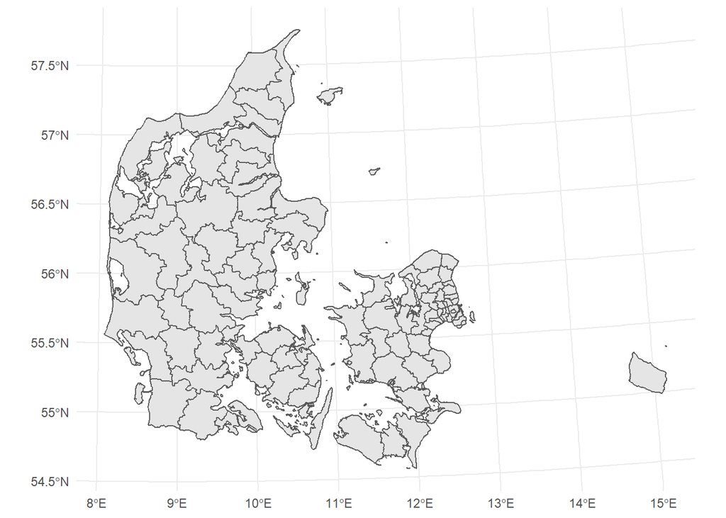

```r
ggplot() +
  geom_sf(data = denmark) +
  theme_minimal()
```

Use the data from problem 5 to make a heatmap of the most transited waters. Hint: Plot the grids on top colour encoded.

**Solution**

First I filter the grid data removing the points outside Denmark.

```r
ais_df_filtered <- ais_df_sum2 %>%
  filter(X > 7, X < 16, Y > 54, Y < 58)
```

Simple plot:

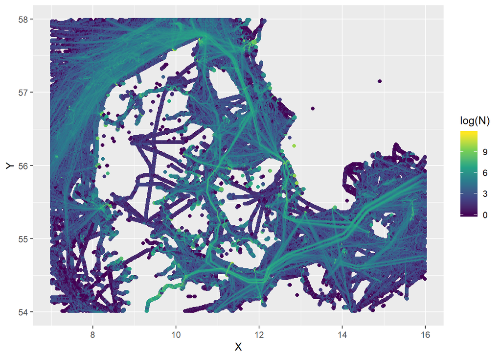

```r
ggplot(data = ais_df_filtered) +
  geom_point(mapping = aes(x = X, y = Y, colour = log(N))) +
  scale_colour_viridis_c()
```

Convert to `sf` object, making it easier to overlap with the map of Denmark.

```r
ais_sf <- ais_df_filtered %>%
  st_as_sf(coords = c("X","Y")) %>%
  st_set_crs(value = 4326) #The reference of the coordinate system
```

```r
ais_sf
```

```
## Simple feature collection with 128119 features and 1 field
## geometry type:  POINT
## dimension:      XY
## bbox:           xmin: 7.01 ymin: 54.01 xmax: 15.99 ymax: 57.99
## epsg (SRID):    4326
## proj4string:    +proj=longlat +datum=WGS84 +no_defs
## # A tibble: 128,119 x 2
##        N     geometry
##    <int>  <POINT [°]>
##  1     9 (7.01 54.14)
##  2     8 (7.01 54.15)
##  3     8  (7.01 54.2)
##  4     3 (7.01 54.39)
##  5     8 (7.01 54.41)
##  6    17 (7.01 54.43)
##  7     5 (7.01 54.53)
##  8    13 (7.01 54.58)
##  9     4 (7.01 54.59)
## 10    12 (7.01 54.67)
## # ... with 128,109 more rows
```

How does it look now?

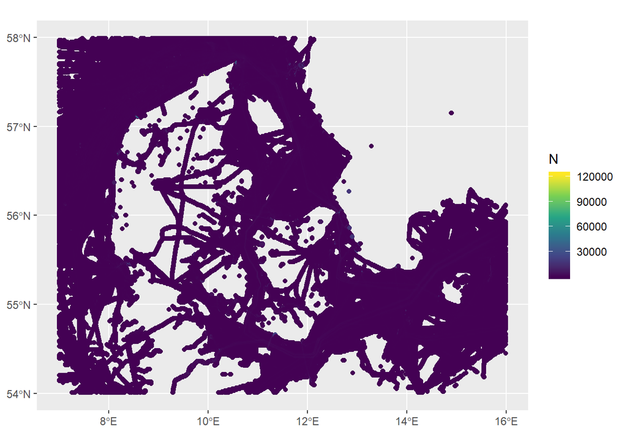

```r
ggplot() +
  geom_sf(data = ais_sf, mapping = aes(colour = N)) +
  scale_colour_viridis_c()
```

First attempt at combining them:

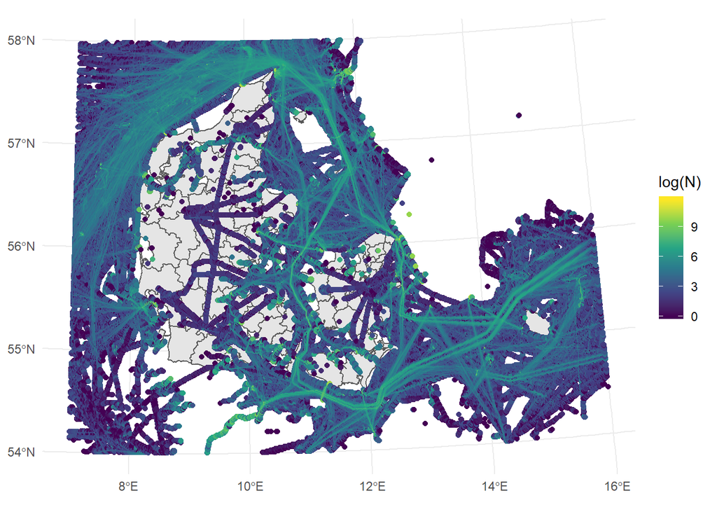

```r
ggplot() +
  geom_sf(data = denmark) +
  geom_sf(data = ais_sf, mapping = aes(colour = log(N))) +
  scale_colour_viridis_c() +
  theme_minimal()
```

There is a lot of points inside the country. A simple way of making it look nicer is to change the order of plotting, so that the map of Denmark is plotted last in stead:

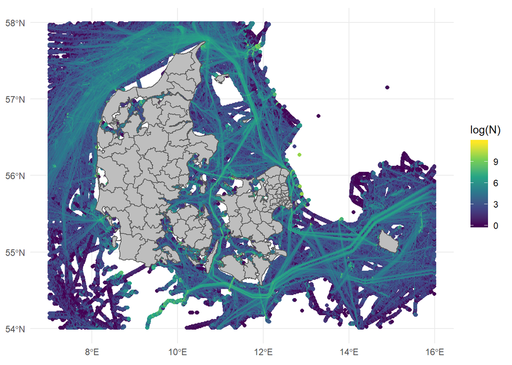

```r
ggplot() +
  geom_sf(data = ais_sf, mapping = aes(colour = log(N))) +
  geom_sf(data = denmark, fill = "grey") +
  scale_colour_viridis_c() +
  theme_minimal()
```

Note: In order to make a proper grid plot we would need to plot squared polygons in stead of simple dots, but the interpretation and method would be the same.